# A Comparison of Fandango against other ratings websites.

```python
import pandas as pd
movies = pd.read_csv("fandango_score_comparison.csv")
```

### Dataset of Ratings by Movie across various ratings websites:

```python
movies.head()
```

|  | FILM | RottenTomatoes | RottenTomatoes_User | Metacritic | Metacritic_User | IMDB | Fandango_Stars | Fandango_Ratingvalue | RT_norm | RT_user_norm | ... | IMDB_norm | RT_norm_round | RT_user_norm_round | Metacritic_norm_round | Metacritic_user_norm_round | IMDB_norm_round | Metacritic_user_vote_count | IMDB_user_vote_count | Fandango_votes | Fandango_Difference |
| --- | --- | --- | --- | --- | --- | --- | --- | --- | --- | --- | --- | --- | --- | --- | --- | --- | --- | --- | --- | --- | --- |
| 0 | Avengers: Age of Ultron (2015) | 74 | 86 | 66 | 7.1 | 7.8 | 5.0 | 4.5 | 3.70 | 4.3 | ... | 3.90 | 3.5 | 4.5 | 3.5 | 3.5 | 4.0 | 1330 | 271107 | 14846 | 0.5 |
| 1 | Cinderella (2015) | 85 | 80 | 67 | 7.5 | 7.1 | 5.0 | 4.5 | 4.25 | 4.0 | ... | 3.55 | 4.5 | 4.0 | 3.5 | 4.0 | 3.5 | 249 | 65709 | 12640 | 0.5 |
| 2 | Ant-Man (2015) | 80 | 90 | 64 | 8.1 | 7.8 | 5.0 | 4.5 | 4.00 | 4.5 | ... | 3.90 | 4.0 | 4.5 | 3.0 | 4.0 | 4.0 | 627 | 103660 | 12055 | 0.5 |
| 3 | Do You Believe? (2015) | 18 | 84 | 22 | 4.7 | 5.4 | 5.0 | 4.5 | 0.90 | 4.2 | ... | 2.70 | 1.0 | 4.0 | 1.0 | 2.5 | 2.5 | 31 | 3136 | 1793 | 0.5 |
| 4 | Hot Tub Time Machine 2 (2015) | 14 | 28 | 29 | 3.4 | 5.1 | 3.5 | 3.0 | 0.70 | 1.4 | ... | 2.55 | 0.5 | 1.5 | 1.5 | 1.5 | 2.5 | 88 | 19560 | 1021 | 0.5 |

5 rows × 22 columns

```python
import matplotlib.pyplot as plt #Imports the plotting module
%matplotlib inline
```

### A Histogram of Fandango Ratings:

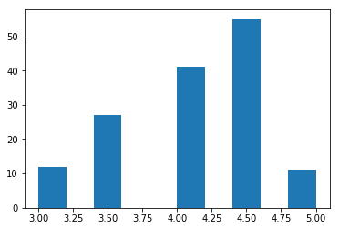

```python
plt.hist(movies["Fandango_Stars"])
plt.show()
```

### A Histogram of Metacritic Ratings:

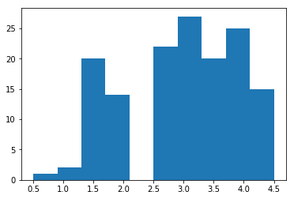

```python
plt.hist(movies["Metacritic_norm_round"])
plt.show()
```

```python
import numpy as np
```

```python
fandango_stars_mean = round(movies["Fandango_Stars"].mean(),2)
metacritic_norm_mean = round(movies["Metacritic_norm_round"].mean(),2)
fandango_stars_median = round(np.median(movies["Fandango_Stars"]))
metacritic_norm_median = round(np.median(movies["Metacritic_norm_round"]))
fandango_stars_stdev = np.std(movies["Fandango_Stars"])
metacritic_norm_stdev = np.std(movies["Metacritic_norm_round"])
print "Fandango Mean Rating:", fandango_stars_mean, "Metacritic Mean Rating:", metacritic_norm_mean
print "Fandango Median Rating:", fandango_stars_median, "Metacritic Median Rating:", metacritic_norm_median
print "Fandango Std.Dev of Rating:", fandango_stars_stdev, "Metacritic Std.Dev of Rating:", metacritic_norm_stdev
```

```
Fandango Mean Rating: 4.09 Metacritic Mean Rating: 2.97
Fandango Median Rating: 4.0 Metacritic Median Rating: 3.0
Fandango Std.Dev of Rating: 0.53853216127 Metacritic Std.Dev of Rating: 0.987561029704
```

### Metacritic methodology:

From the Metacritic website - Metascore is a weighted average in that we assign more importance, or weight, to some critics and publications than others, based on their quality and overall stature. In addition, for music and movies, we also normalize the resulting scores (akin to "grading on a curve" in college), which prevents scores from clumping together.

As Metacritic uses critics reviews only, one could assume that critics will tend to be more conservative in their ratings than the average movie goer.

### Fandango methodology:

A cursory glance at the Fandango website will garner you the idea that Fandango uses its Users reviews to calculate th score as opposed to Metacritic which uses only critic ratings in its methodology. You could assume that their ratings would naturally be higher than Metacritics.

As such a comparison between the two sites might not tell the correct picture as opposed to comparing Fandango to a site like IMDB or Rotten Tomatoes Users Reviews.

### Reading the Mean, Median and Standard Deviation Values for Fandango and Metacritic:

The median value for the Metacritic score is higher than the mean value as there will likely be lower ratings that will drag the mean down from the median value.

The median value for the Fandango score is lower than the mean because there will likely be higher ratings that will drag the mean up from the median value.

The standard deviation for the Fandango scores are lower than the standard deviation for the Metacritic score because the Fandango scores tend to be more concentrated, for example there are no values before 3 stars, unlike Metacritic for which ratings range from 0-5.

### Fandango vs. Metacritics Ratings as a Scatterplot

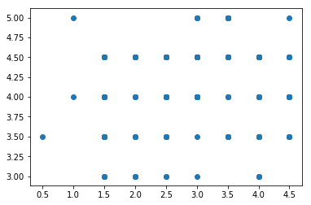

```python
plt.scatter(movies["Metacritic_norm_round"], movies["Fandango_Stars"])
plt.show()
```

### The 5 films with the largest ratings differences between Fandango and Metacritic

```python
movies["fm_diff"] = np.abs(movies["Metacritic_norm_round"] - movies["Fandango_Stars"])
movies.sort_values("fm_diff", ascending=False)[0:5]
```

|  | FILM | RottenTomatoes | RottenTomatoes_User | Metacritic | Metacritic_User | IMDB | Fandango_Stars | Fandango_Ratingvalue | RT_norm | RT_user_norm | ... | RT_norm_round | RT_user_norm_round | Metacritic_norm_round | Metacritic_user_norm_round | IMDB_norm_round | Metacritic_user_vote_count | IMDB_user_vote_count | Fandango_votes | Fandango_Difference | fm_diff |
| --- | --- | --- | --- | --- | --- | --- | --- | --- | --- | --- | --- | --- | --- | --- | --- | --- | --- | --- | --- | --- | --- |
| 3 | Do You Believe? (2015) | 18 | 84 | 22 | 4.7 | 5.4 | 5.0 | 4.5 | 0.90 | 4.20 | ... | 1.0 | 4.0 | 1.0 | 2.5 | 2.5 | 31 | 3136 | 1793 | 0.5 | 4.0 |
| 85 | Little Boy (2015) | 20 | 81 | 30 | 5.9 | 7.4 | 4.5 | 4.3 | 1.00 | 4.05 | ... | 1.0 | 4.0 | 1.5 | 3.0 | 3.5 | 38 | 5927 | 811 | 0.2 | 3.0 |
| 47 | Annie (2014) | 27 | 61 | 33 | 4.8 | 5.2 | 4.5 | 4.2 | 1.35 | 3.05 | ... | 1.5 | 3.0 | 1.5 | 2.5 | 2.5 | 108 | 19222 | 6835 | 0.3 | 3.0 |
| 19 | Pixels (2015) | 17 | 54 | 27 | 5.3 | 5.6 | 4.5 | 4.1 | 0.85 | 2.70 | ... | 1.0 | 2.5 | 1.5 | 2.5 | 3.0 | 246 | 19521 | 3886 | 0.4 | 3.0 |
| 134 | The Longest Ride (2015) | 31 | 73 | 33 | 4.8 | 7.2 | 4.5 | 4.5 | 1.55 | 3.65 | ... | 1.5 | 3.5 | 1.5 | 2.5 | 3.5 | 49 | 25214 | 2603 | 0.0 | 3.0 |

5 rows × 23 columns

### Correlation between Fandango and Metacritics Ratings

```python
from scipy.stats import pearsonr
r_value, p_value = pearsonr(movies["Fandango_Stars"], movies["Metacritic_norm_round"])
print "The correlation r-value is:", r_value
```

```
The correlation r-value is: 0.178449190739
```

The correlation between the two values is 0.17 which indicates that there is very little correlation between the two and no linear relationship.

```python
from scipy.stats import linregress
slope, intercept, r_value, p_value, slope_std_error = linregress(movies["Metacritic_norm_round"], movies["Fandango_Stars"])
predicted_fandango3 = 3 * slope + intercept
predicted_fandango1 = 1 * slope + intercept
predicted_fandango5 = 5 * slope + intercept
print "The predicted Fandango rating with a Metacritic rating of 3 is:", round(predicted_fandango3,2)
print "The predicted Fandango rating with a Metacritic rating of 1 is:", round(predicted_fandango1,2)
print "The predicted Fandango rating with a Metacritic rating of 5 is:", round(predicted_fandango5,2)
```

```
The predicted Fandango rating with a Metacritic rating of 3 is: 4.09
The predicted Fandango rating with a Metacritic rating of 1 is: 3.9
The predicted Fandango rating with a Metacritic rating of 5 is: 4.29
```

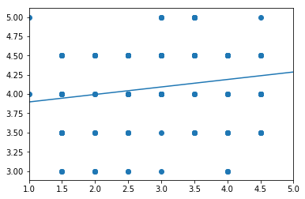

```python
plt.scatter(movies["Metacritic_norm_round"], movies["Fandango_Stars"])
plt.plot([1,5],[predicted_fandango1,predicted_fandango5])
plt.xlim(1.0,5.0)
plt.show()
```